# data based_final

Hyeonho Lee

2018년 9월 6일

```r
library(ggplot2)
library(dplyr)
library(car)
dat <- read.csv('C:/workspace/Github/snu_edu/2 semester/DataBased Statistical Decision Model/기말과제/Final/mobility.csv')
```

```r
dat
```

[output not shown]

[output cut: 5921 more lines]

1. A map of mobility
1. Make a plot where the x and y coordinates are longitude and latitude, and mobility is indicated by color (possibly grey scale), by a third coordinate, or some other suitable device. Make sure your map is legible. Describe the geographic pattern in words. [logitude, latitude, mobility 변수의 값을 나타내는 그래프를 그리세요. X 축과 Y 축이 longitude 와 latitude 로 된 그래프를 만들어 Mobility 변수의 값을 색을 이용하거나, 차원을 늘리거나 또는 다른 방법을 이용해서 표시하세요. 그래프는 읽기 편하도록 만들고, 그래프를 통해서 발견된 mobility의 지리적 경향을 말로 설명하세요. ]

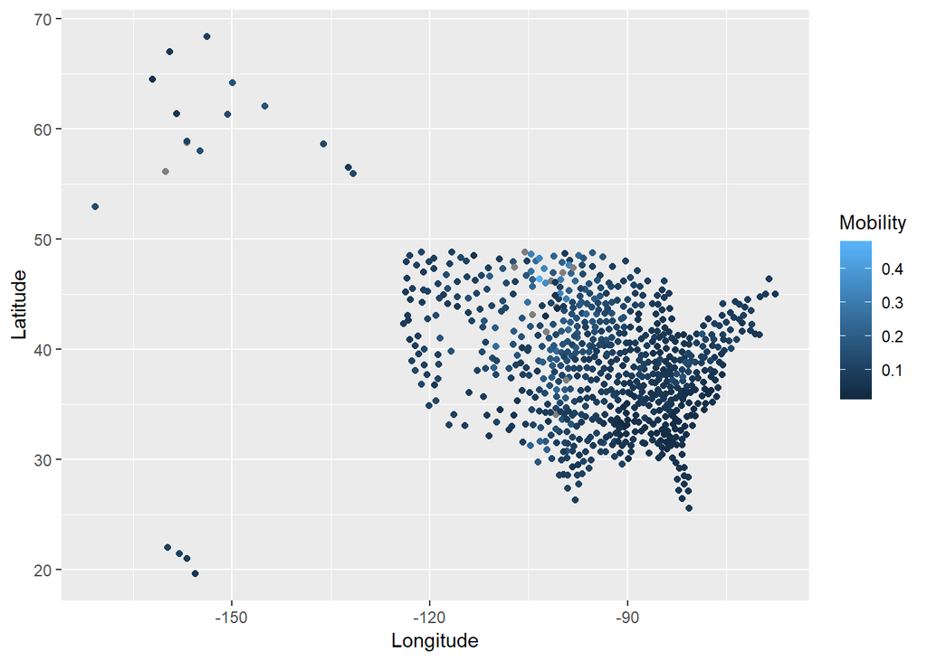

```r
ggplot(dat, aes(x = Longitude, y = Latitude, color = Mobility)) + geom_point()
```

2. Discretizing the Mobility values may enhance visualizing. Create a new variable, called MobilityCat with values high if Mobility > 0.1, and low otherwise. Make a plot where the x and y coordinates are longitude and latitude, and the categorized mobility (i.e. MobilityCat) is indicated by color. This time, filter your observations so that only the continental part of USA is visible (that is, remove data corresponding to Alaska and Hawaii). Has the geographic pattern become clearer? [ Mobility 변수의 값을 몇 개의 카테고리로 나누면 그래프의 가독성을 높일 수가 있습니다. MobilityCat이라는 이름의 새 변수를 만드세요. 새 변수의 값은 mobility > 0.1 이면 high, 그렇지 않으면 low 로 주면 됩니다. 새로운 변수의 값이 색으로 표현된 그래프를 새로 만드세요. 이 그래프는 위 문제와 같이 x, y축이 위도와 경도이 되도록 그리면 됩니다. 이번에는 알래스카와 하와이를 제외한 미 대륙 본토만을 표시합니다. Mobility의 지리적 경향이 더 확실하게 보이나요? ]

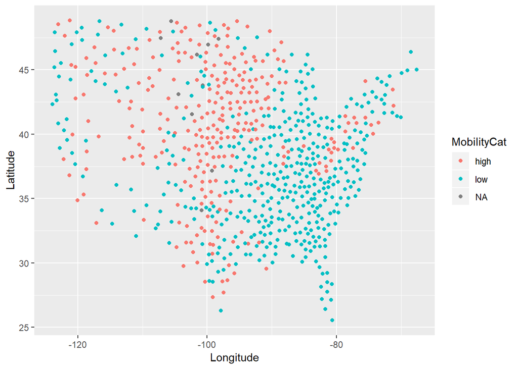

```r
dat$MobilityCat = dat$Mobility
dat$MobilityCat[dat$MobilityCat>0.1] = 'high'
dat$MobilityCat[dat$MobilityCat<=0.1] = 'low'

dat %>% filter(State != 'HI' & State != 'AK') %>%
  ggplot(aes(x = Longitude, y = Latitude, color = MobilityCat)) + geom_point()
```

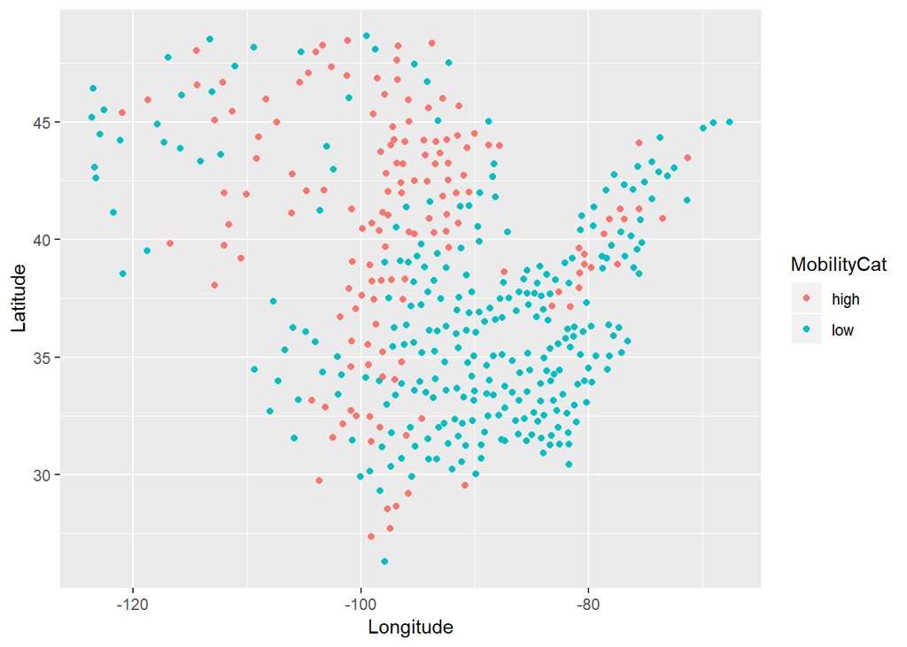

```r
dat %>% filter(State != 'HI' & State != 'AK') %>% na.omit(MobilityCat) %>%
  ggplot(aes(x = Longitude, y = Latitude, color = MobilityCat)) + geom_point()
```

2. A bunch of simple regression models Make scatter plots of mobility against each of the following variables. Include on each plot a line for the simple or univariate regression, and give a table of the regression coefficients. Carefully explain the interpretation of each coefficient. Do any of the results seem odd? [ Y축을 Mobility로하는 하면서 다음의 리스트에 있는 변수를 X축의 값으로 하는 그래프를 각각 그리세요. 적합된 회귀선을 각각의 그래프에 추가하며, 적합된 coefficient 의 값을 테이블에 정리하고, 각각의 coefficient를 해석하세요. 적합 결과에 대해 간단히 논하세요. ]
1. Population
2. Mean household income per capita
3. Racial segregation
4. Income share of the top 1%
5. Mean school expenditures per pupil
6. Violent crime rate
7. Fraction of workers with short commutes.

```r
dat <- read.csv('C:/workspace/Github/snu_edu/2 semester/DataBased Statistical Decision Model/기말과제/Final/mobility.csv')
```

```r
par(mflow = c(4, 2))
```

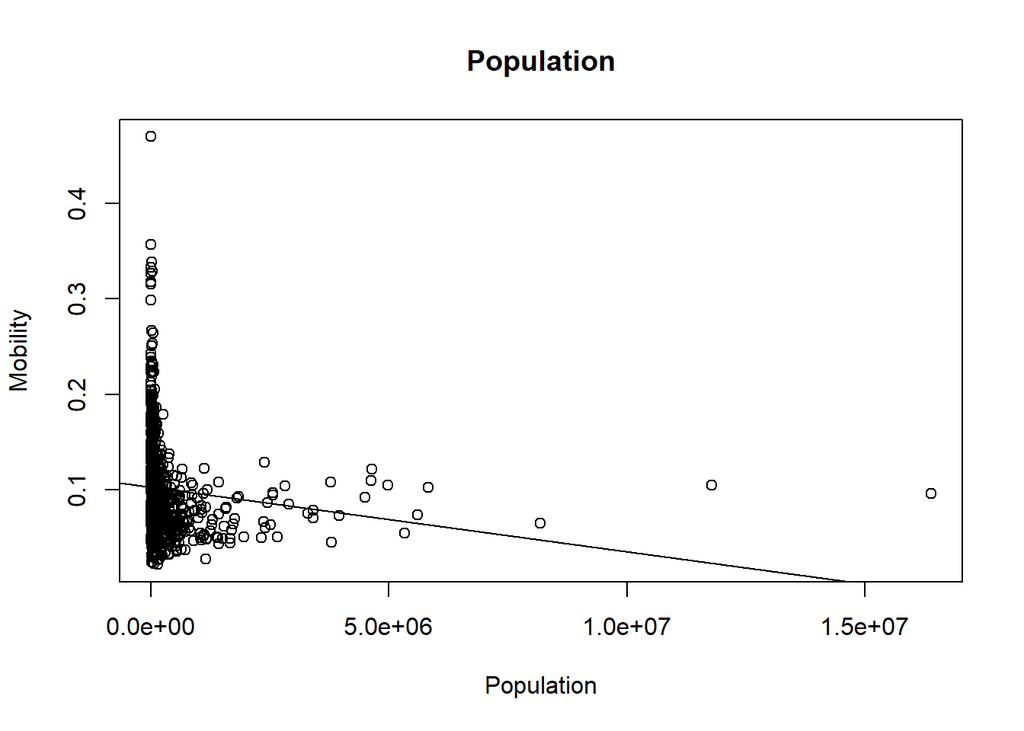

```r
model1 = lm(Mobility~Population, data = dat)
plot(y = dat$Mobility, x = dat$Population, main = 'Population', xlab = 'Population', ylab = 'Mobility')
abline(model1)
```

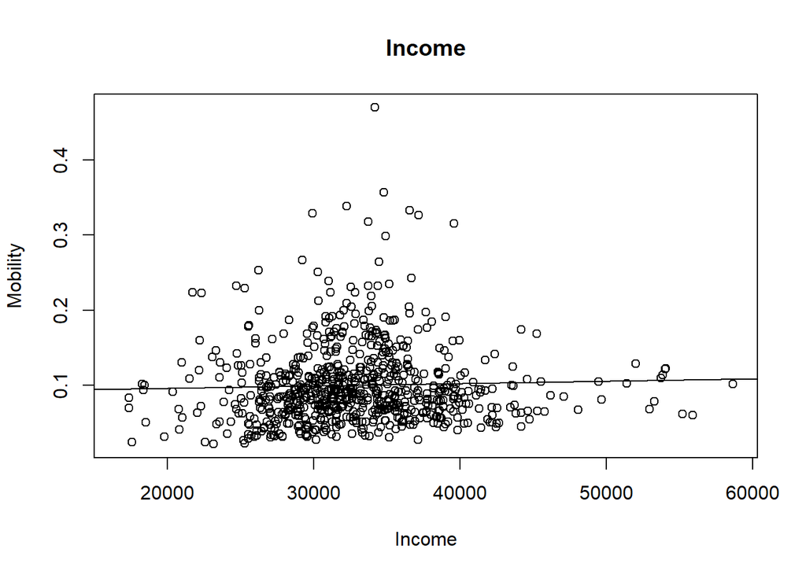

```r
model2 = lm(Mobility~Income, data = dat)
plot(y = dat$Mobility, x = dat$Income, main = 'Income', xlab = 'Income', ylab = 'Mobility')
abline(model2)
```

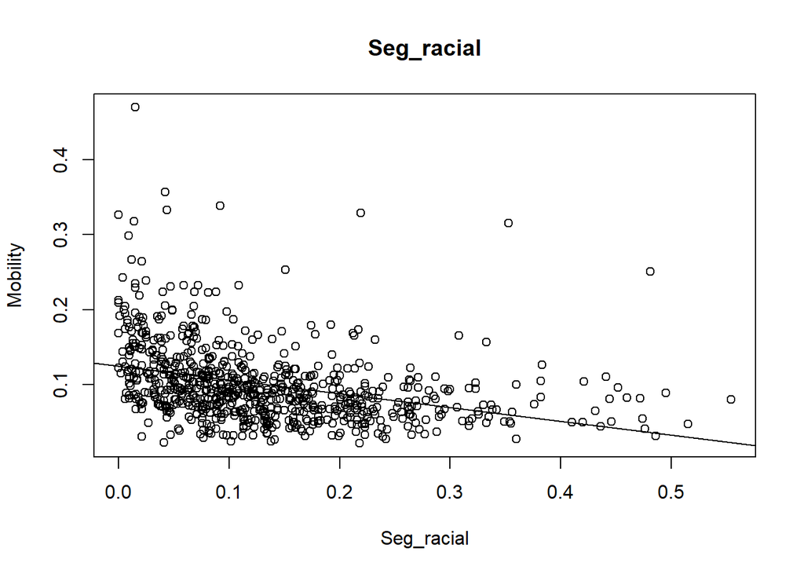

```r
model3 = lm(Mobility~Seg_racial, data = dat)
plot(y = dat$Mobility, x = dat$Seg_racial, main = 'Seg_racial', xlab = 'Seg_racial', ylab = 'Mobility')
abline(model3)
```

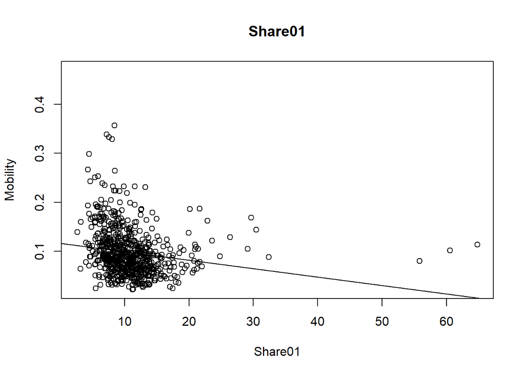

```r
model4 = lm(Mobility~Share01, data = dat)
plot(y = dat$Mobility, x = dat$Share01, main = 'Share01', xlab = 'Share01', ylab = 'Mobility')
abline(model4)
```

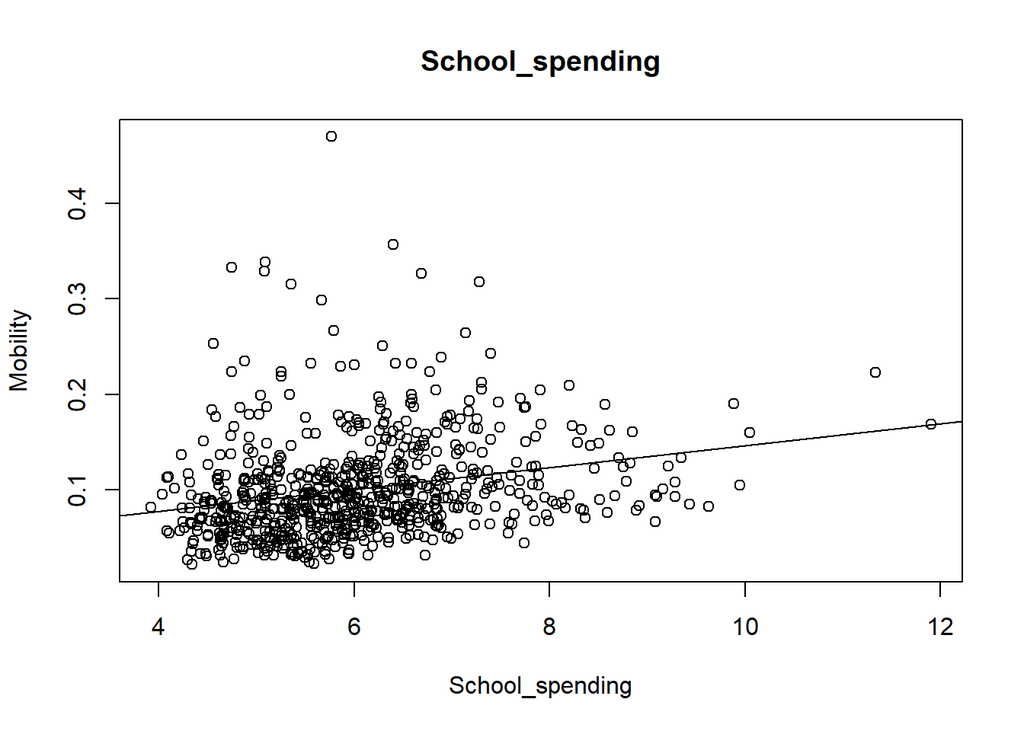

```r
model5 = lm(Mobility~School_spending, data = dat)
plot(y = dat$Mobility, x = dat$School_spending, main = 'School_spending', xlab = 'School_spending', ylab = 'Mobility')
abline(model5)
```

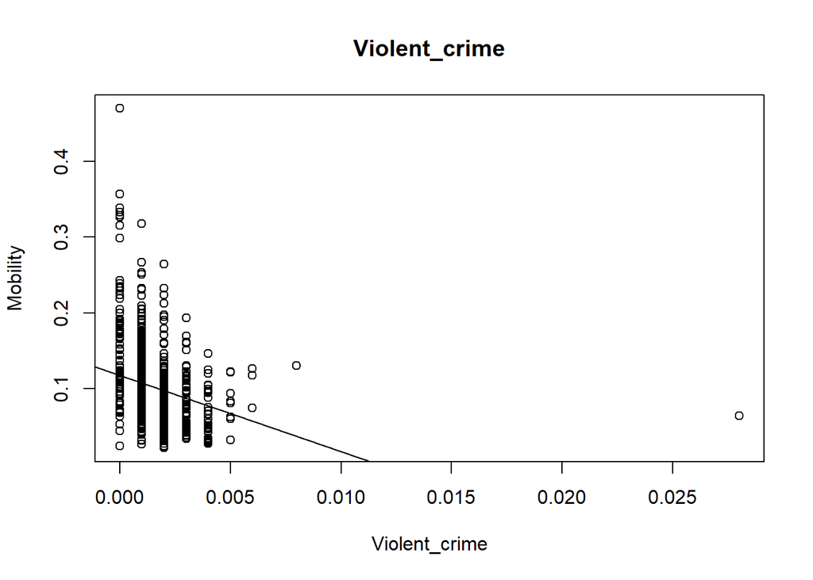

```r
model6 = lm(Mobility~Violent_crime, data = dat)
plot(y = dat$Mobility, x = dat$Violent_crime, main = 'Violent_crime', xlab = 'Violent_crime', ylab = 'Mobility')
abline(model6)
```

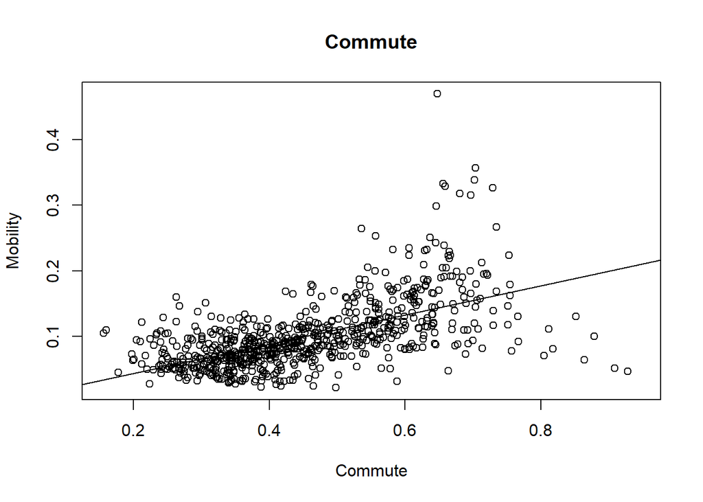

```r
model7 = lm(Mobility~Commute, data = dat)
plot(y = dat$Mobility, x = dat$Commute, main = 'Commute', xlab = 'Commute', ylab = 'Mobility')
abline(model7)
```

```r
rbind(summary(model1)$coef, summary(model2)$coef, summary(model3)$coef, summary(model4)$coef, summary(model5)$coef, summary(model6)$coef,
summary(model7)$coef)
```

```
##                      Estimate   Std. Error     t value      Pr(>|t|)
## (Intercept)      1.030221e-01 2.059279e-03 50.02826083 1.280347e-237
## Population      -6.732228e-09 1.834666e-09 -3.66945699  2.608342e-04
## (Intercept)      9.024633e-02 1.133468e-02  7.96196280  6.518812e-15
## Income           3.094097e-07 3.394621e-07  0.91147051  3.623496e-01
## (Intercept)      1.246090e-01 3.037536e-03 41.02304317 2.293515e-191
## Seg_racial      -1.835019e-01 1.839327e-02 -9.97657802  4.680267e-22
## (Intercept)      1.162509e-01 4.207370e-03 27.63030629 1.572651e-114
## Share01         -1.718199e-03 3.518374e-04 -4.88350207  1.289615e-06
## (Intercept)      3.167886e-02 1.017010e-02  3.11490137  1.913271e-03
## School_spending  1.146429e-02 1.662318e-03  6.89656930  1.169495e-11
## (Intercept)      1.176149e-01 2.834322e-03 41.49666043 7.553132e-191
## Violent_crime   -1.005057e+01 1.294377e+00 -7.76479603  2.909666e-14
## (Intercept)     -1.972589e-04 5.336157e-03 -0.03696647  9.705219e-01
## Commute          2.218695e-01 1.124225e-02 19.73533719  9.376468e-70
```

```r
coef_1 = rbind(summary(model1)$coef, summary(model2)$coef, summary(model3)$coef, summary(model4)$coef, summary(model5)$coef, summary(model6)$coef,
summary(model7)$coef)
```

3. All things considered Run a linear regression of mobility against all appropriate covariates. [ 적절한 설명변수들을 이용하여 다중회귀분석을 실시합니다. ]
1. Report all regression coefficients and their standard errors; you may use either a table or a figure as you prefer. [ 적합된 계수의 값과 그 standard error를 보여주세요. ]

```r
model = lm(Mobility~., data = na.omit(dat[,-2])); summary(model)$coef
```

```
##                                Estimate   Std. Error      t value
## (Intercept)                7.961796e-02 9.069732e-02  0.877842469
## ID                         1.282588e-07 3.243982e-07  0.395374532
## StateAR                   -8.757664e-03 9.306101e-03 -0.941066931
## StateAZ                   -1.685349e-02 2.897736e-02 -0.581608819
## StateCA                   -3.522625e-02 2.807289e-02 -1.254814074
## StateDC                    3.012009e-03 2.639539e-02  0.114111193
## StateDE                   -1.234427e-02 2.190646e-02 -0.563498881
## StateFL                   -2.791515e-02 2.333399e-02 -1.196329942
## StateGA                   -2.631079e-02 9.218941e-03 -2.853992768
## StateIA                   -3.916472e-03 1.502799e-02 -0.260611856
## StateID                   -7.019439e-02 2.358582e-02 -2.976125952
## StateIL                   -2.575657e-02 1.566755e-02 -1.643943509
## StateIN                    3.441189e-03 1.604155e-02  0.214517198
## StateKS                   -3.805657e-02 1.430407e-02 -2.660541430
## StateKY                   -1.016146e-02 1.054101e-02 -0.963993307
## StateLA                   -4.731745e-03 1.146373e-02 -0.412757997
## StateMA                   -1.456664e-02 3.025570e-02 -0.481450871
## StateMD                   -1.388464e-02 1.845855e-02 -0.752206547
## StateME                   -7.621443e-03 2.476081e-02 -0.307802669
## StateMN                   -1.490168e-03 1.851520e-02 -0.080483501
## StateMO                   -2.220947e-02 1.185762e-02 -1.873012462
## StateMS                   -6.956457e-03 8.732236e-03 -0.796641007
## StateMT                   -2.842926e-02 2.152640e-02 -1.320669092
## StateNC                   -2.493178e-02 1.158495e-02 -2.152083258
## StateND                    5.186949e-02 1.944326e-02  2.667735815
## StateNE                   -1.432630e-02 1.582552e-02 -0.905265503
## StateNH                   -3.401010e-03 2.538258e-02 -0.133989898
## StateNM                   -2.187890e-02 1.577986e-02 -1.386507930
## StateNV                   -3.629576e-02 2.677473e-02 -1.355597761
## StateNY                   -9.744608e-03 2.021333e-02 -0.482088137
## StateOH                   -2.825718e-02 1.711120e-02 -1.651385070
## StateOK                   -1.499352e-03 1.285908e-02 -0.116598653
## StateOR                   -6.160507e-02 2.548332e-02 -2.417466647
## StatePA                   -6.380757e-03 1.725129e-02 -0.369871311
## StateRI                    1.027285e-02 2.850483e-02  0.360389916
## StateSC                   -2.393003e-02 1.155679e-02 -2.070646799
## StateSD                   -7.144935e-03 1.756694e-02 -0.406726212
## StateTN                   -9.949725e-03 1.161139e-02 -0.856893896
## StateTX                   -1.869023e-02 1.359616e-02 -1.374669653
```

[output cut: 111 more lines]

```
## Labor_force_participation 5.390013e-02
## Manufacturing             1.458523e-06
## Chinese_imports           9.806474e-01
## Teenage_labor             4.283474e-01
## Migration_in              5.057342e-01
## Migration_out             1.776329e-02
## Foreign_born              4.976921e-02
## Social_capital            3.065330e-02
## Religious                 6.033284e-01
## Violent_crime             8.965025e-01
## Single_mothers            2.876792e-03
## Divorced                  2.123299e-01
## Married                   5.963060e-01
## Longitude                 1.572658e-01
## Latitude                  8.380120e-01
```

```r
coef_2 = summary(model)$coef
```

2. Explain why the ID variable must be excluded. [ Variable ID는 설명변수로 쓰이지 않습니다. 이유를 설명하세요. ]

```r
# y의 변동과 연관이 전혀 없기 때문에 쓰이지 않는다.
```

3. Explain which other variables, if any, you excluded from the regression, and why. (If you think they can all be used, explain why.) [For this question, do not use any automated variable selection, and try to keep as many variables as possible.] [ 다른 설명변수 중에 모형 적합에 쓰지 않은 변수가 있다면, 왜 제외했는지 설명하세요. 만약 모두 쓰였다면, 그렇게 할 수 있는 이유를 설명하세요. ]

```r
names(summary(model)$coef[,4][summary(model)$coef[,4] < 0.05])
```

```
##  [1] "StateGA"        "StateID"        "StateKS"        "StateNC"
##  [5] "StateND"        "StateOR"        "StateSC"        "Black"
##  [9] "Seg_racial"     "Seg_poverty"    "Commute"        "Middle_class"
## [13] "Manufacturing"  "Migration_out"  "Foreign_born"   "Social_capital"
## [17] "Single_mothers"
```

```r
model = lm(Mobility~., data = na.omit(dat) %>% select(State, Black, Seg_racial, Seg_poverty, Commute, Mobility,
                                                      Middle_class, Manufacturing, Migration_out, Foreign_born, Social_capital, Single_mothers))

coef_3 = summary(model)$coef
# 모두 쓰지않았다. p값이 0.05이상은 값들은 Mobility의 값에 영향을 주지않는다(유의하지않다)라고 판단하고 제거하였다.
```

4. Compare the coefficients you found in problem 2 to the coefficients for the same variables in this regression. Are they significantly different? Have any changed sign? [ 2 번 문제의 답과 다중회귀 분석에서 적합한 coefficient 들을 비교하세요. 다른 값들이 나왔나요? 계수의 부호가 바뀌었나요? ]

```r
coef_1[,1]
```

```
##     (Intercept)      Population     (Intercept)          Income
##    1.030221e-01   -6.732228e-09    9.024633e-02    3.094097e-07
##     (Intercept)      Seg_racial     (Intercept)         Share01
##    1.246090e-01   -1.835019e-01    1.162509e-01   -1.718199e-03
##     (Intercept) School_spending     (Intercept)   Violent_crime
##    3.167886e-02    1.146429e-02    1.176149e-01   -1.005057e+01
##     (Intercept)         Commute
##   -1.972589e-04    2.218695e-01
```

```r
coef_2[,1]
```

```
##               (Intercept)                        ID
##              7.961796e-02              1.282588e-07
##                   StateAR                   StateAZ
##             -8.757664e-03             -1.685349e-02
##                   StateCA                   StateDC
##             -3.522625e-02              3.012009e-03
##                   StateDE                   StateFL
##             -1.234427e-02             -2.791515e-02
##                   StateGA                   StateIA
##             -2.631079e-02             -3.916472e-03
##                   StateID                   StateIL
##             -7.019439e-02             -2.575657e-02
##                   StateIN                   StateKS
##              3.441189e-03             -3.805657e-02
##                   StateKY                   StateLA
##             -1.016146e-02             -4.731745e-03
##                   StateMA                   StateMD
##             -1.456664e-02             -1.388464e-02
##                   StateME                   StateMN
##             -7.621443e-03             -1.490168e-03
##                   StateMO                   StateMS
##             -2.220947e-02             -6.956457e-03
##                   StateMT                   StateNC
##             -2.842926e-02             -2.493178e-02
##                   StateND                   StateNE
##              5.186949e-02             -1.432630e-02
##                   StateNH                   StateNM
##             -3.401010e-03             -2.187890e-02
##                   StateNV                   StateNY
##             -3.629576e-02             -9.744608e-03
##                   StateOH                   StateOK
##             -2.825718e-02             -1.499352e-03
##                   StateOR                   StatePA
##             -6.160507e-02             -6.380757e-03
##                   StateRI                   StateSC
##              1.027285e-02             -2.393003e-02
##                   StateSD                   StateTN
##             -7.144935e-03             -9.949725e-03
##                   StateTX                   StateUT
##             -1.869023e-02             -4.082892e-02
```

[output cut: 27 more lines]

```
##             -1.387002e-02             -9.002426e-02
##             Manufacturing           Chinese_imports
##             -1.361151e-01             -1.621889e-05
##             Teenage_labor              Migration_in
##             -1.692306e+00             -1.714003e-01
##             Migration_out              Foreign_born
##             -7.923862e-01              1.038335e-01
##            Social_capital                 Religious
##             -5.998911e-03              7.277619e-03
##             Violent_crime            Single_mothers
##             -2.178583e-01             -2.703094e-01
##                  Divorced                   Married
##             -2.096998e-01             -3.432992e-02
##                 Longitude                  Latitude
##             -8.860678e-04              2.118894e-04
```

```r
coef_3[,1]
```

```
##    (Intercept)        StateAR        StateAZ        StateCA        StateDC
##   0.0792898339   0.0034076491   0.0325949313   0.0110331170   0.0356060581
##        StateDE        StateFL        StateGA        StateIA        StateID
##  -0.0051927731  -0.0201314417  -0.0232689428   0.0200529055  -0.0274048158
##        StateIL        StateIN        StateKS        StateKY        StateLA
##  -0.0003832763   0.0113770811  -0.0080900878  -0.0024672084   0.0083060918
##        StateMA        StateMD        StateME        StateMN        StateMO
##   0.0098831176  -0.0022372981  -0.0116745119   0.0220117139  -0.0070026623
##        StateMS        StateMT        StateNC        StateND        StateNE
##  -0.0035216190   0.0100177611  -0.0215677502   0.0872763530   0.0138661492
##        StateNH        StateNM        StateNV        StateNY        StateOH
##   0.0099624714   0.0072354903   0.0079788798   0.0094555963  -0.0077903219
##        StateOK        StateOR        StatePA        StateRI        StateSC
##   0.0224237597  -0.0074170474   0.0100659635   0.0268910866  -0.0196402413
##        StateSD        StateTN        StateTX        StateUT        StateVA
##   0.0247393909  -0.0008198406   0.0147295364   0.0095948567  -0.0006002617
##        StateWA        StateWI        StateWV        StateWY          Black
##   0.0106370802   0.0143682711   0.0093107966   0.0362124577   0.1156965145
##     Seg_racial    Seg_poverty        Commute   Middle_class  Manufacturing
##  -0.0601005896  -0.0959009486   0.0490426169   0.1885116739  -0.1360263624
##  Migration_out   Foreign_born Social_capital Single_mothers
##  -1.1032903013   0.1479850365  -0.0022734918  -0.3847465604
```

```r
# 다른값나옴, 계수의 부호가 바뀌었음.
```

5. Take a look at the variation inflation factor for each variable. Report those variables with VIF greater than 10. Do you suspect a (nearly) multicollinearity? If so, give a reason for, and suggest a way to avoid it. [ Variation inflation factor (VIF) 를 보고, VIF 가 10 보다 큰 변수들을 찾으세요. Multicollinearity가 있다고 의심이 되나요? 그렇다면, 이유를 대고, multicollinearity를 피할 수 있는 방법을 제시하세요. ]

```r
model = lm(Mobility~., data = na.omit(dat) %>% select(State, Black, Seg_racial, Seg_poverty, Commute, Mobility,
                                                      Middle_class, Manufacturing, Migration_out, Foreign_born, Social_capital, Single_mothers))
vif(model)
```

```
##                      GVIF Df GVIF^(1/(2*Df))
## State          201.228846 43        1.063621
## Black            8.334129  1        2.886889
## Seg_racial       1.911333  1        1.382510
## Seg_poverty      3.058966  1        1.748990
## Commute          4.441063  1        2.107383
## Middle_class     8.036978  1        2.834956
## Manufacturing    2.641479  1        1.625263
## Migration_out    2.315049  1        1.521528
## Foreign_born     2.298690  1        1.516143
## Social_capital   6.678766  1        2.584331
## Single_mothers   8.463415  1        2.909195
```

```r
# state가 201으로 10을 넘는 공선성을 띄고 있다고 의심이 된다. State가 같은 컬럼인 행이 좀 있는듯... 이건 나중에 찾아보자
# multicollinearity를 피하기 위해 변수를 제거한다.
```

4. Please in my front yard
1. Inspect the missingness pattern in variables Colleges, Tuition and Graduation. [Note: NA is a missing value.] How many observations have no measurements for these variables? [ 변수 Colleges, Tuition and Graduation에는 기록되지 않은 값(missing value)가 많이 있습니다. 얼마나 많은 관측값에서 이 변수들의 값이 기록되지 않았나요? ]

```r
dat <- read.csv('C:/workspace/Github/snu_edu/2 semester/DataBased Statistical Decision Model/기말과제/Final/mobility.csv')
```

```r
sum(is.na(dat[,'Colleges']))
```

```
## [1] 157
```

```r
sum(is.na(dat[,'Tuition']))
```

```
## [1] 161
```

```r
sum(is.na(dat[,'Graduation']))
```

```
## [1] 160
```

2. Did the missing values happen at random? To answer this, plot a scatter of Mobility and Population (choose a suitable scale for Population), and inspect which data points have missing values in (all of, or some of) variables Colleges, Tuition and Graduation. [누락된 값이 임의로 형성되었나요? 대답을 하기 위해서, Mobility와 Population의 scatter plot을 그리고, 어떤 관측값에서 전술한 세 변수의 값이 누락되었는지 조사하세요. ]

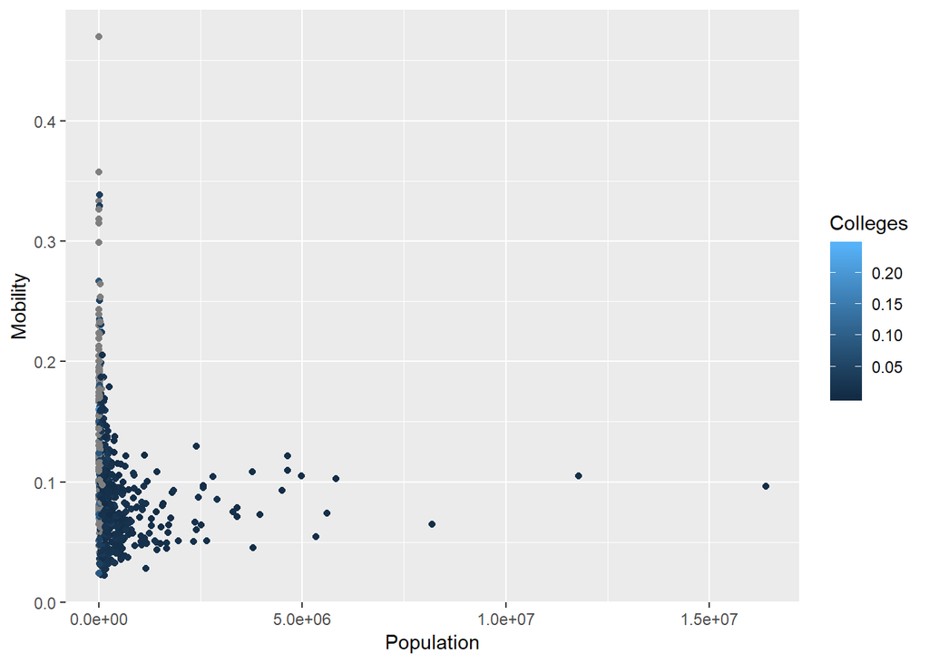

```r
ggplot(dat, aes(x = Population, y = Mobility)) + geom_point(aes(color = Colleges))
```

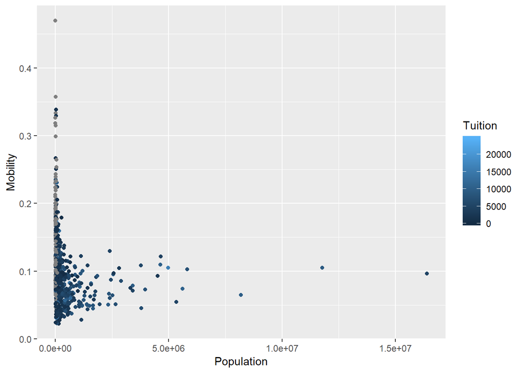

```r
ggplot(dat, aes(x = Population, y = Mobility)) + geom_point(aes(color = Tuition))
```

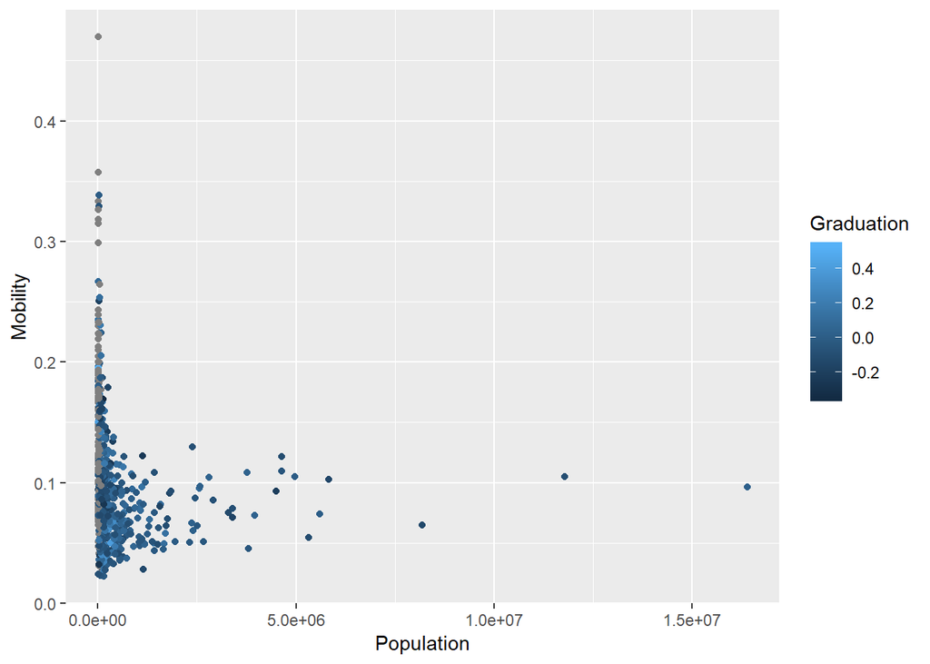

```r
ggplot(dat, aes(x = Population, y = Mobility)) + geom_point(aes(color = Graduation))
```

```r
# 이렇게 보면 비교하기도 어렵고 뭐가 누락됏는지 잘모르겠다.
```

3. Create a new variable, called HE, whose value is TRUE if there is a higher education institution in the community, is FALSE if not. Replace all NA values in variables Colleges, Tuition and Graduation with 0. [ HE 라는 이름의 새 변수를 만드세요. 각 community (관측값) 에 고등 교육기관이 있다면 HE 의 값은 TRUE, 그렇지 않다면 FALSE로 줍니다. 전술한 세 변수의 NA 값은 모두 0 으로 바꿉니다. ]

```r
dat['Colleges'][is.na(dat['Colleges'])] = 0
dat['Tuition'][is.na(dat['Tuition'])] = 0
dat['Graduation'][is.na(dat['Graduation'])] = 0

dat$HE[dat$Colleges > 0 & dat$Tuition > 0 & dat$Graduation > 0] = TRUE
dat$HE[!(dat$Colleges > 0 & dat$Tuition > 0 & dat$Graduation > 0)] = FALSE
```

5. All things considered, again. Fit a linear regression model, incorporating your findings in problems 3 and 4. If you have removed, created, or modified variables, explain. Report all regression coefficients and their standard errors. Use this model for all problems below. [3번과 4번 문제의 답을 포함하여 새로운 다중 회귀 분석모형을 세우고, 적합합니다. 새로운 변수를 만들거나, 어떤 변수를 지웠다면, 설명하세요. 모든 coefficient의 값과 그 standard error를 보여주세요. 아래의 문제에는 이 모형을 이용합니다. ]

```r
model = lm(Mobility ~ Black + Seg_racial + Seg_poverty + Commute + Middle_class + Manufacturing +
             Migration_out + Foreign_born + Social_capital + Single_mothers + HE + Colleges + Tuition + Graduation, data = dat)

# 3번에서 VIF가 높았던 State를 제거하고, 4번에서 언급한 고등교육현황과 새로 만든 컬럼인 HE를 사용한 회귀분석을 실시하였다.
summary(model)
```

```
##
## Call:
## lm(formula = Mobility ~ Black + Seg_racial + Seg_poverty + Commute +
##     Middle_class + Manufacturing + Migration_out + Foreign_born +
##     Social_capital + Single_mothers + HE + Colleges + Tuition +
##     Graduation, data = dat)
##
## Residuals:
##       Min        1Q    Median        3Q       Max
## -0.083395 -0.015348 -0.002247  0.011108  0.179206
##
## Coefficients:
##                  Estimate Std. Error t value Pr(>|t|)
## (Intercept)     1.111e-01  2.054e-02   5.410 8.77e-08 ***
## Black           9.846e-02  1.538e-02   6.402 2.87e-10 ***
## Seg_racial     -1.872e-02  1.388e-02  -1.348  0.17796
## Seg_poverty    -4.112e-02  6.194e-02  -0.664  0.50703
## Commute         9.570e-02  1.486e-02   6.439 2.28e-10 ***
## Middle_class    1.311e-01  2.810e-02   4.666 3.70e-06 ***
## Manufacturing  -1.528e-01  1.696e-02  -9.007  < 2e-16 ***
## Migration_out  -5.754e-01  1.794e-01  -3.207  0.00141 **
## Foreign_born    1.161e-01  2.834e-02   4.096 4.71e-05 ***
## Social_capital  9.471e-04  1.405e-03   0.674  0.50040
## Single_mothers -5.128e-01  4.345e-02 -11.802  < 2e-16 ***
## HETRUE         -5.055e-03  3.362e-03  -1.503  0.13323
## Colleges        3.067e-02  6.106e-02   0.502  0.61560
## Tuition         3.042e-07  3.574e-07   0.851  0.39498
## Graduation     -7.355e-03  1.289e-02  -0.571  0.56847
## ---
## Signif. codes:  0 '***' 0.001 '**' 0.01 '*' 0.05 '.' 0.1 ' ' 1
##
## Residual standard error: 0.0279 on 676 degrees of freedom
##   (50 observations deleted due to missingness)
## Multiple R-squared:  0.6673, Adjusted R-squared:  0.6604
## F-statistic: 96.84 on 14 and 676 DF,  p-value: < 2.2e-16
```

```r
model = lm(Mobility ~ Black +  Commute + Middle_class + Manufacturing +
             Migration_out + Foreign_born + Single_mothers + HE, data = dat)
summary(model)
```

```
##
## Call:
## lm(formula = Mobility ~ Black + Commute + Middle_class + Manufacturing +
##     Migration_out + Foreign_born + Single_mothers + HE, data = dat)
##
## Residuals:
##       Min        1Q    Median        3Q       Max
## -0.100540 -0.016006 -0.003298  0.011800  0.182744
##
## Coefficients:
##                 Estimate Std. Error t value Pr(>|t|)
## (Intercept)     0.114737   0.019404   5.913 5.26e-09 ***
## Black           0.099975   0.015116   6.614 7.45e-11 ***
## Commute         0.088427   0.010440   8.470  < 2e-16 ***
## Middle_class    0.139443   0.025088   5.558 3.88e-08 ***
## Manufacturing  -0.148450   0.015979  -9.290  < 2e-16 ***
## Migration_out  -0.662955   0.159872  -4.147 3.79e-05 ***
## Foreign_born    0.099894   0.026886   3.715 0.000219 ***
## Single_mothers -0.543592   0.040038 -13.577  < 2e-16 ***
## HETRUE         -0.005325   0.002297  -2.318 0.020741 *
## ---
## Signif. codes:  0 '***' 0.001 '**' 0.01 '*' 0.05 '.' 0.1 ' ' 1
##
## Residual standard error: 0.02854 on 698 degrees of freedom
##   (34 observations deleted due to missingness)
## Multiple R-squared:  0.6452, Adjusted R-squared:  0.6411
## F-statistic: 158.7 on 8 and 698 DF,  p-value: < 2.2e-16
```

```r
# p-value 0.05낮은 변수들은 다 제거햇다. HE가 굉장히 높아 당혹스럽다.
```

6. Make a map of predicted mobility. Make a map of the model’s predicted mobility. How does it compare, qualitatively, to the map of actual mobility? [5번의 모형을 이용하여 예측한 mobility를 ( 1번과 같이 ) 지도 위에 표시합니다. 실제 관측값의 지도와 비교하세요. ]

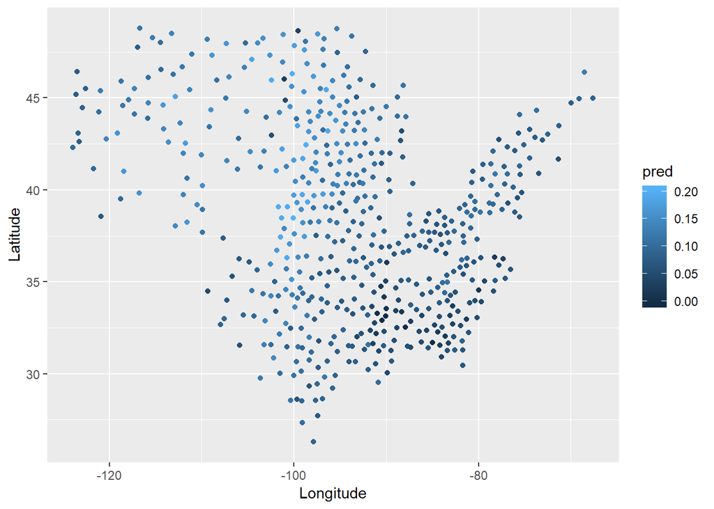

```r
model = lm(Mobility ~ Black +  Commute + Middle_class + Manufacturing +
             Migration_out + Foreign_born + Single_mothers + HE, data = dat)
pred = predict(model, newdata = dat)



pred = cbind(pred, dat)
pred %>% filter(State != 'HI' & State != 'AK') %>% na.omit(pred) %>%
  ggplot(aes(x = Longitude, y = Latitude, color = pred)) + geom_point()
```

```r
# 나름 비슷하다.
```

7. Just because I was there Find Pittsburgh in the data set. For this question, assume that the model (you have fitted just before) is well-fitted.
1. What its actual mobility? What is its predicted mobility, according to the model?
2. Holding all else fixed, what is the predicted mobility if the violent crime rate is doubled? If it is halved?
3. Provide a 95% confidence interval for the expected mobility at Pittsburgh.
4. Provide a 95% prediction interval for the expected mobility at Pittsburgh. Explain the difference.